# Earnings of Recent Graduates: A Machine Learning Approach

Will Doyle

10/24/2021

# First Year Earnings of Bachelor’s Degree Holders

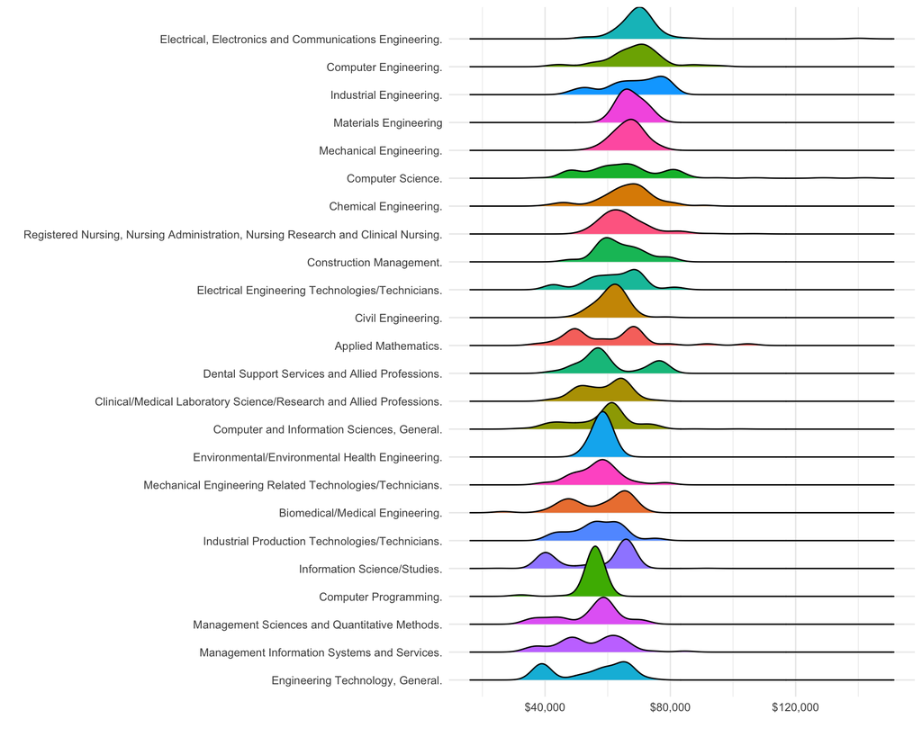

# First Year Earnings of Associate Degree Holders

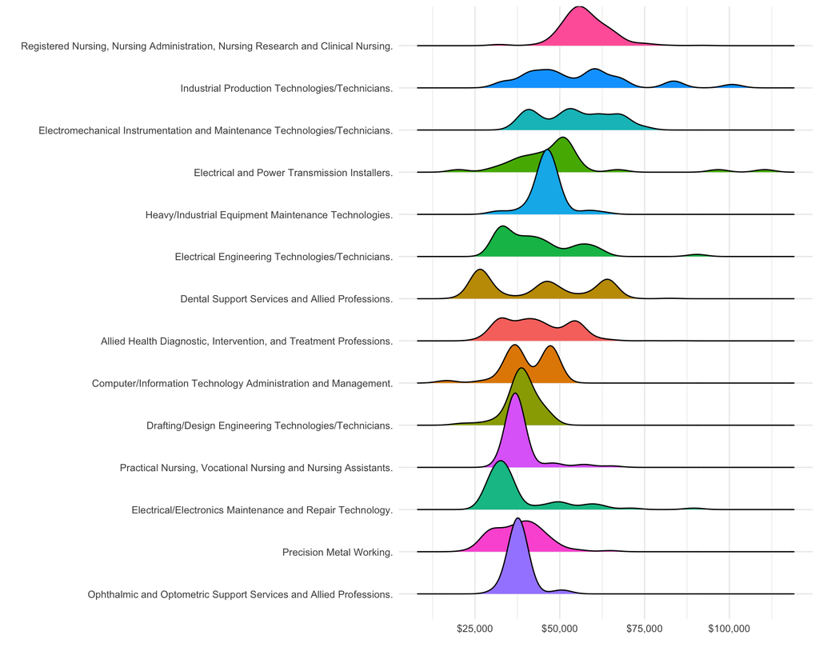

# First Year Earnings of Certificate Holders

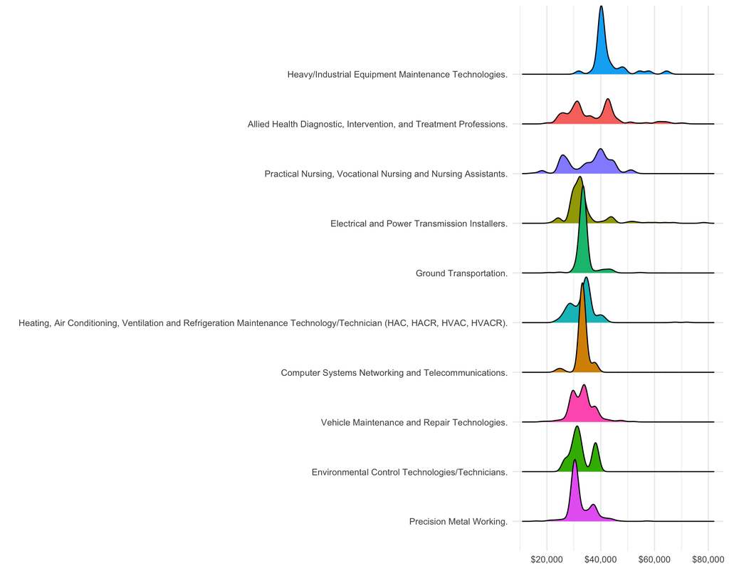

# The Two Worlds of Current Applied Data Analysis

- Theory driven: testing hypotheses about a specific population parameter

To what extent do programs in institutions with lower net prices graduate students with higher earnings?

- ML driven

How can we best predict the level of earnings from a given postsecondary program?

My goal is to take the second approach as a contrast to the standard approach I would take to this issue, highlighting the relevant differences and some of the recent improvements in this area.

# Some Contrasts between the “two worlds”

- Covariate selection

  – Theory driven approach assumes a model– a specific (typically linear and additive) model that is useful for understanding the outcome. Emphasis is on estimates of parameters.

  – ML approach uses programmatic approaches to select predictors, with an emphasis on feature engineering for a large number of predictors. Many times coefficient or other parameter estimates are ignored.

# Some Contrasts between the “two worlds”

- Model selection

– Theory driven approach relies on a few workhorse models: OLS and Logistic regression (and variants for other outcomes) in particular.

– ML approach uses a wide variety of predictive models, with an emphasis on model fit over interpretability

# Some Contrasts between the “two worlds”

- Model Fit

– Theory driven approaches are generally fairly indifferent to model fit, relying mostly on measures of fit that focus on variance ($r^2$, log likelihood) as opposed to accuracy (rmse), and rely on measures calculated from the full (training) dataset

– ML approaches

ML focuses on accuracy of the model: rmse for continuous outcomes, sensitivity/specificity/AUC for classification. Measures are calculated using cross-validation, many times with a final held out testing dataset.

# The Data

College Scorecard Program Level Data

Program level earnings from 260,000 programs at accredited institutions across the United States. Includes earnings and debt level and repayment information for programs. Dependent variable: Median earnings from graduates of the program after 1 year (using social security records)

```r
pr_df<-read_csv(here("data","raw","Most-Recent-Cohorts-Field-of-Study.csv"),
                     na = c("PrivacySuppressed","NULL")
                )%>%
  clean_names(case="snake")%>%
  filter(credlev<4)%>% ## UG degrees only
  filter(!is.na(earn_mdn_hi_1yr))%>% ## Complete data
  select(opeid6,creddesc,cipdesc, earn_mdn_hi_1yr) ## just id vars and earnings
```

# The Data

College Scorecard College Level Data

Characteristics of 6,700 accredited institutions of postsecondary education across the United States. A total of 2,392 variables.

```r
## Load in scorecard data
cb_df<-read_csv(here("data","raw","Most-Recent-Cohorts-All-Data-Elements.csv"),
                 na=c("PrivacySuppressed","NULL"))%>%
  clean_names(case="snake")%>%
  mutate(opeid6=as.character(opeid6))
```

# The Data

American Community Survey

Zip-code level data from 33,000 zip codes, matched to institution zip code. Data from the [American Community Survey API](https://www.census.gov/data/developers/data-sets.html), as made easy to use by [tidycensus](https://walker-data.com/tidycensus/) I include four characteristics of each zip code:

- Percent of population with at least a bachelor’s degree
- Percent of population with incomes over $75,000
- Percent of population that owns their own home
- Percent of population that move into the zip code in the last year.

```r
educ <- get_acs(
  geography = my_geo,
  variables = var_list,
  output = "wide",
  year = 2019
)
```

# Workflow Approach

Project uses the `tidymodels` approach, which involves standardizing steps in data analysis into a workflow. Workflows usually contain the following elements:

- A recipe: used to preprocess data
- A model: model specification
- A fit: Fitting model to preprocessed data

Tidymodels makes tuning and cross validting models *much* easier than it was in past iterations, such as `caret`

[More about tidymodels here](https://www.tidymodels.org/)

# Feature Engineering

“Wrangling” before preprocessing

- Dropping all non “rate” variables
- Dropping id variables

```r
cb_df<-
  cb_df%>%
  select(!contains("num"))%>% # Count
  select(!contains("_n"))%>% #count
  select(!contains("count"))%>% # I am the count ah ah ah....
  select(!contains("sd"))%>% #standar deviation
  select(!contains("earn"))%>% #overalignment with outcome
  select(!contains("den"))%>% # denominator, again
  select(!contains("url"))%>% # url
  select(!matches("^(cip\\d{2})"))%>% ## cip codes from scorecard
  select(-st_fips)%>% # duplicate var
  select(-c(latitude,longitude))%>% #id var
  select(-accredagency)%>% #duplicate
  select(-unitid)%>% #duplcicate id
  select(-fedschcd) #duplicate id
```

# Feature Engineering

“Wrangling” before preprocessing

- Dropping variables with extensive missing data

```r
prop_miss<-.25

keep_names<-
  cb_df%>%
  summarise_all(prop_na)%>%
  select(which(.<prop_miss))%>%
  names()

cb_df<-cb_df%>%
  select(all_of(keep_names))
```

# Feature Engineering

“Wrangling” before preprocessing

- Recoding any variable with less than 100 distinct values as a factor

```r
## Min and max values
n_unique_min<-100
n_unique_max<-length(unique(cb_df$opeid6))

cb_df<-cb_df%>%
  mutate_if( ~ (n_distinct(.) < n_unique_min), as.factor)%>% ## recode few distinct as factors
  group_by(opeid6)%>%  ##
  select_if((~(n_distinct(.)!=n_unique_max)))%>% ## drop replicate id vars
  ungroup()
```

# Feature Engineering:

Preprocesing steps:

- Drop missing data: `step_naomit`
- Recode rare categories to other: `step_other`
- Recode categorical to binary: `step_dummy`
- Drop zero variance/near zero variance predictors: `step_zv`, `step_nzv`
- Drop any highly correlated predictors (threshold r>.95) : `step_corr`

```r
## Pre-processing via recipe
earn_recipe<-recipe(cb_df,earn_formula) %>%
  update_role(opeid6,new_role="id variable")%>%
  update_role(-opeid6,new_role="predictor")%>%
  update_role(earn_mdn_hi_1yr,new_role="outcome")%>%
  step_naomit(all_predictors())%>%
  step_other(all_nominal_predictors(),threshold = .005)%>%
  step_dummy(all_nominal_predictors())%>%
  step_zv(all_predictors(),skip=TRUE) %>%
  step_nzv(all_numeric_predictors(),skip=TRUE)%>%
  step_normalize(all_numeric_predictors())%>%
  step_corr(all_numeric_predictors(),skip=TRUE,threshold = .95)
```

Results in a dataset with 27,000 observations, 514 predictors, one id variable, one dependent variable.

# Cross Validation

I use kfold cross validation, with 20 distinct folds. Model is trained on 95 percent of the data and tested against 5 percent of the data, with the rmse calculated from the testing dataset each time.

```r
cb_rs<-vfold_cv(cb_df,v = 20)
```

# Model Selection

– Linear Model with Elastic Net Regularization

Elastic net is a combination of the lasso penalty, which drops some subset of highly correlated predictors, and the ridge penalty, which shrinks coefficients of correlated penalties toward one another

– Two “hyperparameters:” penalty and mixture

[figure not shown]

Source: Hasite, Qian, Tay (2021) [Introduction to glmnet](https://glmnet.stanford.edu/articles/glmnet.html)

# Elastic net model specification

```r
## Create empty workflow
earn_wf<-workflow()

## Add recipe
earn_wf<-earn_wf%>%
  add_recipe(earn_recipe)

## Add enet model
enet_fit<-
  linear_reg(penalty=tune(),
             mixture=tune()) %>%
  set_engine("glmnet")

## Set tuning grid
enet_grid<-expand_grid(penalty=seq(0,1,by=.333),
                       mixture=seq(0.05,1,by=.45))

## Add model to workflow
earn_wf<-earn_wf%>%
  add_model(enet_fit)

## Fit model to resampled data, tune hyperparameters
earn_wf_fit<-
  tune_grid(
    earn_wf,
    resamples=cb_rs, ##resampling plan
    grid=enet_grid # tuning grid
  )
```

# Random Forest Regression

Random forest is an extension of a tree-based approach, which uses random subsets of cases and variables to “vote” on the likely outcome for a given covariate. It’s not restrained by linearity.

[figure not shown]

Source: Hastie, Tibshirani, Friedman (2007) Elements of Statistical Learning, p. 588

# Random Forest Regression

Two hyperparameters: minimum n before closing a tree, number of variables to try

```r
earn_prep<-prep(earn_recipe)
## Next model: random forest

tune_spec <- rand_forest(
  mtry = tune(),
  trees = 1000,
  min_n = tune()
) %>%
  set_mode("regression") %>%
  set_engine("ranger")

tune_wf <- workflow() %>%
  add_recipe(earn_recipe) %>%
  add_model(tune_spec)

doParallel::registerDoParallel()

tune_res <- tune_grid(
  tune_wf,
  resamples = cb_rs,
  grid = 20
)
```

# Elastic Net: Model Tuning

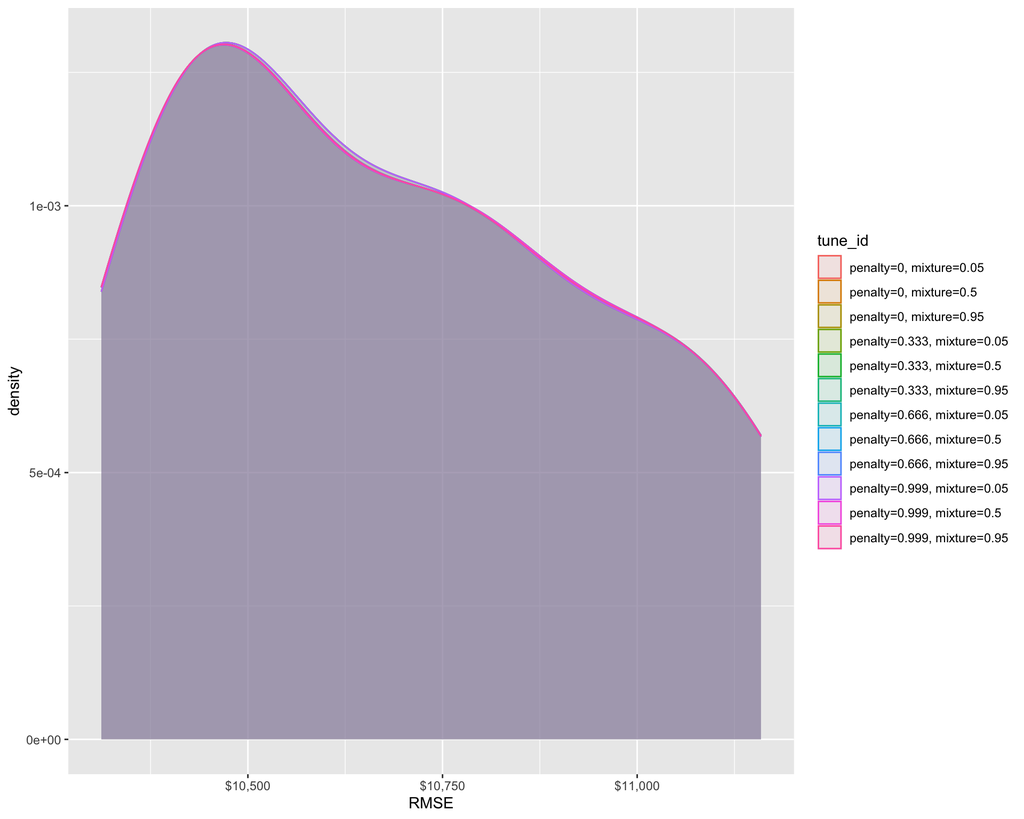

# Elastic Net: Estimates

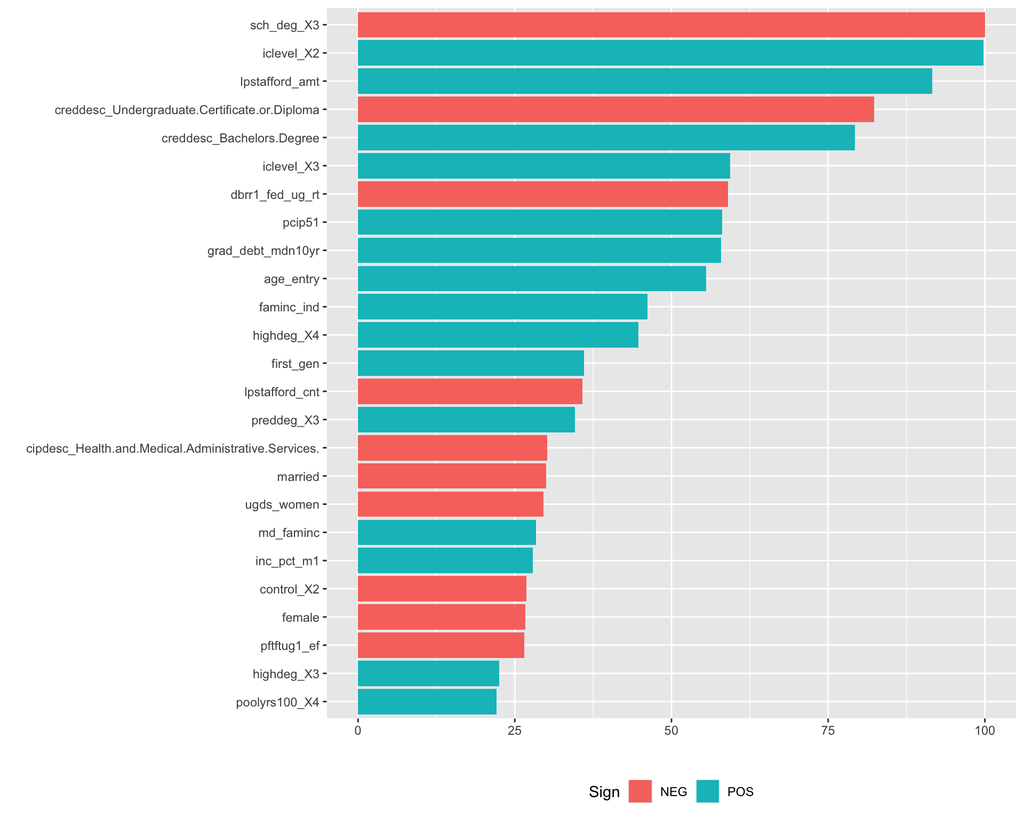

# Elastic Net: Model fit and conclusions

- Expected results: school type, degree type
- Unexpected results: Overall debt repayment rates, “carried” debt are clear predictors

# Random Forest: Model Tuning

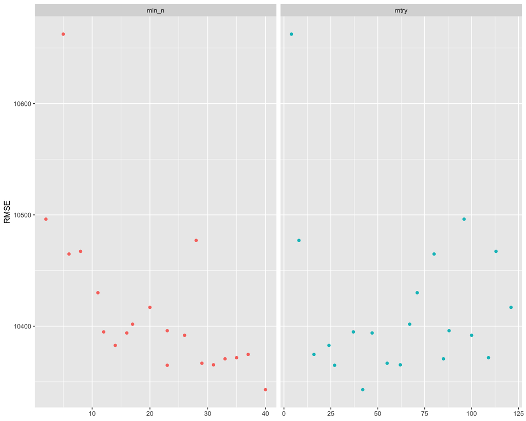

# Random Forest: Variable importance

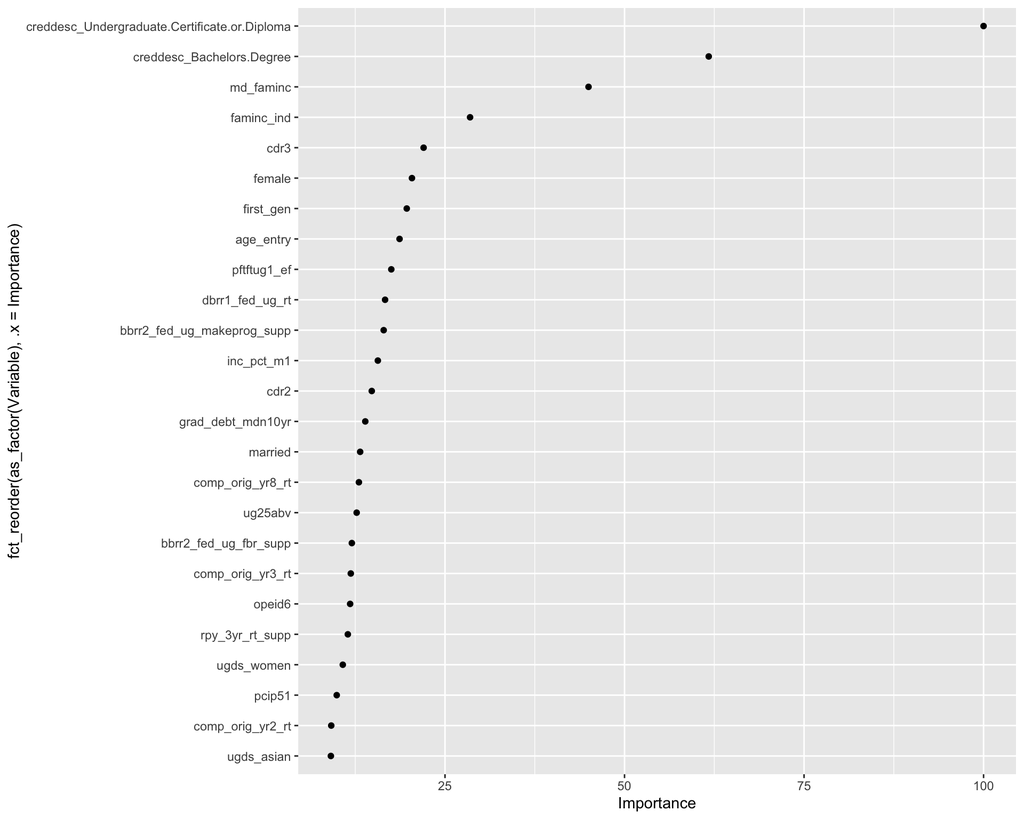

# Random Forest: Model fit and conclusions

– Expected: Institution and degree type

– Unexpected: Cohort default rates, satisfactory academic progress rates

Overall model fit is slightly better, but not substantively improved.

# Takeaways

– Overall model accuracy remains low: RMSE ~$10,000

– Novel features are highlighted: things I didn’t expect and might be worth exploring further

– Predictions could be of use in recommendation algorithms: set a min and max salary, add in other considerations, here’s the type of program that could be considered

– Cross validation and model fit based on accuracy should be more widely used

– “Hybrid” Approaches: random propensity forests